# SUMMARY OF THE ANALYSIS

## KEY ISSUES

The following are points to be addressed in this summary:

1. The original data has a format where there is one observation per account type, format the data so that there is now one observation per participant.
2. Create two dummy variables for whether each participant is:
   - financially excluded
   - digitally financially included

     Then state the overall rates of financial exclusion and digital financial inclusion for the combined population of these three districts.
3. Describe in a few short paragraphs how the mobile money market is divided between the three companies and include at least one chart or table to illustrate your findings.
4. Is there any statistically significant difference in the share of customers who have experienced failed mobile money transactions in rural and urban villages? Explain your findings including any assumptions and limitations.
5. What variables are good predictors that someone will cancel their mobile money account? Discuss what causes a customer to stop using their mobile money account including how strong the evidence is.

### ISSUE 2

This requires the creation of two dummy variables based on the values of a particular column then finding the overall rates of financial exclusion and inclusion for the combined population of the three districts.  
After the creation of the new variables and analysis, it can be noted that the number of fInancially included participants are 1073 while the number of financially excluded participants are 132.  
The chart below shows the distribution of financial inclusion and exclusion for the combined population of the three districts.

<sup>Financially included - This means they have at least one registered account with a mobile money operator or an online bank account.</sup>  
<sup>Financially excluded - This means they haven't registered for any type of financial account.</sup>

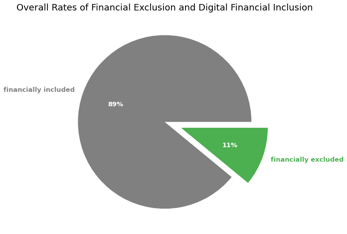

### ISSUE 3

Having checked the mobile money market distribution across the three companies using the main mobile money account of each participant, Company_A has the highest market share with 59.5% of the total market share while Company_B has the second largest market share with 38.8% and lastly, Company_C has the least market share by a large margin having less than 2% of the total market share.

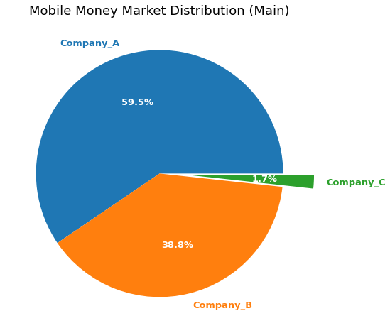

It's worth noting that some participants have more than one mobile money account so it'll be interesting to see how the distribution between the companies change since there would be a joint market share between the companies.

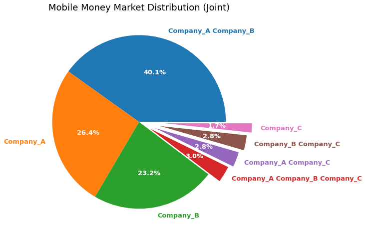

### ISSUE 4

Before comparing the difference between the customers transactions in different locations, it is worth noting that majority of the customers stay in the Rural area as this might have an effect on further analysis.

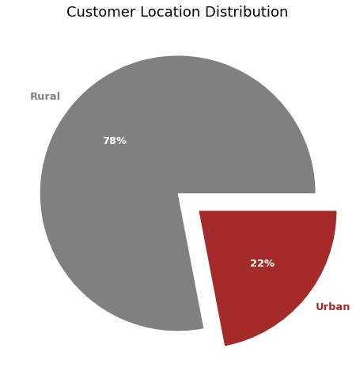

The chart below shows how the `v240` column affects the customers in each location.  
<sub>(the `v240` column represents whether or not the transaction failed to go through. with `no` meaning `the transaction never failed` and `yes` meaning `the transaction failed to go through`)</sub>

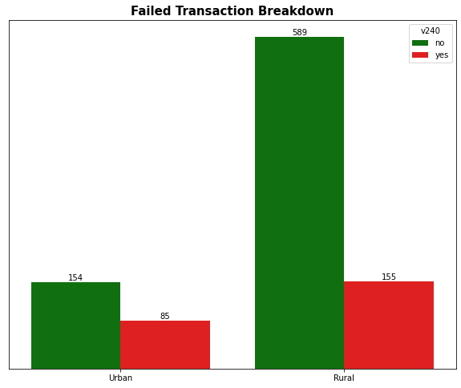

With the breakdown above, it is noticed that the Rural area has a higher number of failed transactions compared to the Urban area but this might be caused by the majority of the customers staying in the Rural area as stated earlier.

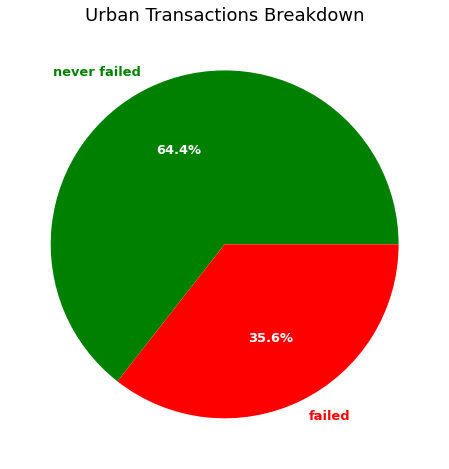

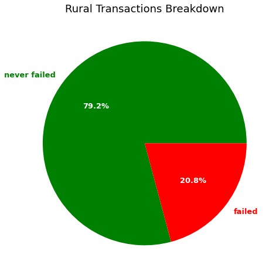

The charts above show the seperate breakdown of each location, and it can be noted that the Rural area has a lower percentage of failed transactions with 20.8% when compared with the Urban area which had 35.6% of failed transactions.